# Computing a SPFI

Last updated on October 8, 2018

# SPFI to FPA Inputs

## Program flow

Note the following order of operations: 1. Read in HRJ data 2. Create a SPFI Input Object a. Stock and ages to include in the index b. Catch time series by SPFI fishery strata c. ERA fisheries that are to be used to compute SPFI d. Define the SPFI fishery strata

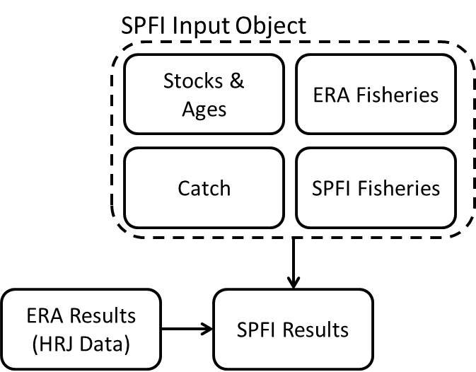

# Step-by-step instructions on how to use the code

## Load functions

The first thing you need to do is load all the functions:

```r
source("Code/GarciaFunLibrary.R")
source("Code/SPFIFunLibrary.R")
source("Code/SPFItoFPAfun.R")
```

## Load HRJ data

The SPFI is computed using output from the CTC’s exploitation rate analysis program CoShak12. The core data needed for SPFI computations are saved in what are called HRJ files. Data from HRJ files can be obtained in one of two ways: from a HRJ database or from the list of HRJ files used to create the HRJ database. For this example I will use the latter, but note that both options are available.

```r
#Read in HRJ files in a directory
 by=readHRJdir("Data/HRJ/2018", nFisheries=79, straysinescap=TRUE, Age6="include")
#Convert to CY layout
 cy=convertHRJ_BYtoCY(by)
#Convert HRJ from R to Access format
 z.cy=convertHRJ_RtoAccess(cy)
#add the 'preferred' table to the Access format
 z.cy = addPTableHRJ(z.cy, hrjclass = "Access")
```

## Create a SPFI input object

Lastly, to compute a SPFI we will need a SPFI input object.

```r
#SPFI input data is a list object
 afishery=list()
#Which fisheries?
 afishery$erafisheries = 1:3
#Combine fisheries?
 afishery$combinefisheries = data.frame(ERAFishery=c(1,2,3), SPFIFishery=c(1,2,1))
#Stock/age matrix
 afishery$stockage = data.frame(StockAcronym=factor(c("era stock acronym 1", "era stock acronym 2", "...")), Age2 = c(0,0,0), Age3=c(1,0,0), Age4=c(1,1,0), Age5=c(0,1,0), Age6=c(0,0,0))
#Catch
 afishery$catch = data.frame(Year=rep(1979:1982,2), SPFIFishery=c(rep(1,4),rep(2,4)), SPFIFisheryName=factor(c(rep("SPFI Strata 1",4), rep("SPFI Strata 2",4))), Catch=rpois(8,10), Addon=rpois(8,1))
#Set class
 class(afishery) = "spfi_input"
```

```r
afishery
```

```
## $erafisheries
## [1] 1 2 3
##
## $combinefisheries
##   ERAFishery SPFIFishery
## 1          1           1
## 2          2           2
## 3          3           1
##
## $stockage
##          StockAcronym Age2 Age3 Age4 Age5 Age6
## 1 era stock acronym 1    0    1    1    0    0
## 2 era stock acronym 2    0    0    1    1    0
## 3                 ...    0    0    0    0    0
##
## $catch
##   Year SPFIFishery SPFIFisheryName Catch Addon
## 1 1979           1   SPFI Strata 1     8     0
## 2 1980           1   SPFI Strata 1    13     0
## 3 1981           1   SPFI Strata 1     8     1
## 4 1982           1   SPFI Strata 1    11     1
## 5 1979           2   SPFI Strata 2    10     1
## 6 1980           2   SPFI Strata 2    13     2
## 7 1981           2   SPFI Strata 2     9     1
## 8 1982           2   SPFI Strata 2     7     2
##
## attr(,"class")
## [1] "spfi_input"
```

## Running the program

### Compute SPFI

All that’s left is to compute the SPFI, which is easily done via the spfi function:

```r
spfi(spfidat, hrjdat, hrjtype=c("BY","CY","P"), tolerance=.0000001)
```

where spfidat is a spfi_input object, hrjdat is HRJ data, hrjtype specifies which HRJ data type to use, and tolerance is the desired accuracy. The spfi program returns a spfi_output object. By convention, the SPFI program computes the SPFI with the hrjtype=“BY”; however, the most correct thing to do would be to use hrjtype=“P”.

### Summarizing results

```r
summary(x, unit=c("nom cat", "nom tot", "aeq cat", "aeq tot"), baseperiod=1979:1982)
```

where x is a spfi_output object, unit specifies the unit the SPFI index should be in, and baseperiod defines what years to define as the base period.

### Missing strata? No problem

If missing strata are present, then the function gauntlet can be used.

```r
gauntlet(x, method="glm", catchcriteria=4000)
```

```r
summary(x=gauntlet(x), unit=c("nom cat", "nom tot", "aeq cat", "aeq tot"), baseperiod=1979:1982)
```

# Example 1: 2018ERA SEAK AABM Troll for CLB9806

## Create the spfi_input object

```r
#SPFI input data is a list object
 seak=list()
#Which fisheries?
 seak$erafisheries = 1:6
#Combine fisheries?
 seak$combinefisheries = data.frame(rbind(c(1,1),c(2,2),c(3,3),c(4,4),c(5,5),c(6,4)))
 names(seak$combinefisheries) = c("ERAFishery","SPFIFishery")
#Stock/age matrix
 seak$stockage = read.delim("Data/9806/seakTroll.STF", header=TRUE)
#Catch
 seak$catch = read.csv("Data/2018ERA_CatchDataforSPFI/seakTroll7916.CAT",header=FALSE)
 names(seak$catch) = c("Year","SPFIFishery","SPFIFisheryName","Catch","Addon")
#Set the object class
 class(seak) = "spfi_input"
```

Examine the spfi_input object to see what stocks and ages are going to be used in the SPFI computations.

```r
 seak$stockage
```

| StockAcronym | Age2 | Age3 | Age4 | Age5 | Age6 |
| --- | --- | --- | --- | --- | --- |
| AKS | 0 | 0 | 1 | 1 | 1 |
| QUI | 0 | 0 | 1 | 1 | 0 |
| RBT | 0 | 1 | 1 | 1 | 0 |
| SRH | 0 | 0 | 1 | 1 | 0 |
| URB | 0 | 0 | 1 | 1 | 0 |
| WSH | 0 | 0 | 1 | 1 | 0 |

Examine the spfi_input object to see how the SPFI fisheries are defined.

```r
 seak$combinefisheries
```

| ERAFishery | SPFIFishery |
| --- | --- |
| 1 | 1 |
| 2 | 2 |
| 3 | 3 |
| 4 | 4 |
| 5 | 5 |
| 6 | 4 |

## Load the 2018ERA HRJ Data

```r
#Read in HRJ files in a directory
 by=readHRJdir("Data/9806/2018ERA_HRJ", nFisheries=79, straysinescap=TRUE, Age6="include")
#Convert to CY layout
 cy=convertHRJ_BYtoCY(by)
#Convert HRJ from R to Access format
 z.cy=convertHRJ_RtoAccess(cy)
#add the 'preferred' table to the Access format
 z.cy = addPTableHRJ(z.cy, hrjclass = "Access")
```

## Compute SPFI

Note that I have set the hrjtype=“BY” so that this result can be compared with the SEAK AABM Troll SPFI in the 2018 CLB & ERA report.

```r
seak_spfi <- spfi(spfidat=seak, hrjdat=z.cy, hrjtype="BY")
```

## Summarize the results

### AEQ landed catch

```r
summary(x=seak_spfi, unit="aeq cat")
```

```
##  Years spfigrand    1    2    3    4    5
##   1979      0.78 1.22 1.06 0.57 0.70 0.36
##   1980      1.29 0.63 0.95 1.46 1.57 1.84
##   1981      1.14 1.20 1.12 0.91 1.10 0.87
##   1982      0.79 0.95 0.88 1.06 0.62 0.92
##   1983      0.87 1.04 0.58 0.62 1.25 0.82
##   1984      0.62 0.36 0.93 1.07 0.53 0.28
##   1985      0.66 0.44 0.57 0.81 0.82 0.71
##   1986      0.45 0.43 0.15 0.39 1.24 0.54
##   1987      0.47 0.59 0.16 0.53 0.62 1.31
##   1988      0.41 1.37 0.00 0.13 0.64 1.16
##   1989      0.50 0.83 0.20 0.42 0.54 0.51
##   1990      0.69 0.62 0.11 0.85 1.15 1.09
##   1991      0.59 1.34 0.21 0.86 0.78 0.50
##   1992      0.38 1.01 0.06 0.48 0.40 0.21
```

[output cut: 24 more lines]

### AEQ total mortality

```r
summary(x=seak_spfi, unit="aeq tot")
```

```
##  Years spfigrand    1    2    3    4    5
##   1979      0.76 1.18 1.05 0.56 0.67 0.36
##   1980      1.22 0.63 0.91 1.48 1.42 1.75
##   1981      1.14 1.20 1.15 0.89 1.11 0.82
##   1982      0.88 0.99 0.89 1.07 0.79 1.07
##   1983      0.98 1.00 0.59 0.67 1.68 0.75
##   1984      0.65 0.36 0.92 1.05 0.62 0.43
##   1985      0.76 0.46 0.56 0.78 1.07 0.69
##   1986      0.51 0.48 0.15 0.40 1.46 0.62
##   1987      0.53 0.60 0.16 0.49 0.74 1.72
##   1988      0.42 1.29 0.01 0.14 0.65 1.26
##   1989      0.56 0.80 0.20 0.41 0.62 0.58
##   1990      0.86 0.77 0.12 0.90 1.49 1.07
##   1991      0.62 1.26 0.20 0.81 0.82 0.63
##   1992      0.43 0.96 0.06 0.45 0.57 0.22
```

[output cut: 24 more lines]

### Figures

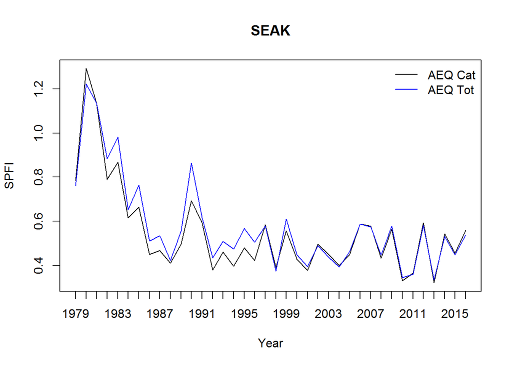

```r
  plot(summary(seak_spfi, unit="aeq cat")$spfi[,1],type="l",xlab="Year",ylab="SPFI",main="SEAK", xaxt="n")
  lines(summary(seak_spfi, unit="aeq tot")$spfi[,1],col="blue")
  legend("topright",c("AEQ Cat", "AEQ Tot"), lty=c(1,1), col=c("black","blue"),bty="n")
  axis(1,at=1:length(1979:2016),labels=1979:2016)
```

# Example 2: 2018ERA SEAK AABM Troll for Base Period Calibration

## Create the spfi_input object

```r
#SPFI input data is a list object
 seak=list()
#Which fisheries?
 seak$erafisheries = 1:6
#Combine fisheries?
 seak$combinefisheries = data.frame(rbind(c(1,1),c(2,2),c(3,3),c(4,4),c(5,5),c(6,4)))
 names(seak$combinefisheries) = c("ERAFishery","SPFIFishery")
#Stock/age matrix
 seak$stockage = read.delim("Data/Phase2/seakTrollbpP2.STF", header=TRUE)
#Catch
 seak$catch = read.csv("Data/2018ERA_CatchDataforSPFI/seakTroll7916.CAT",header=FALSE)
 names(seak$catch) = c("Year","SPFIFishery","SPFIFisheryName","Catch","Addon")
#Set the object class
 class(seak) = "spfi_input"
```

Examine the spfi_input object to see what stocks and ages are going to be used in the SPFI computations.

```r
 seak$stockage
```

| StockAcronym | Age2 | Age3 | Age4 | Age5 | Age6 |
| --- | --- | --- | --- | --- | --- |
| SSA | 0 | 0 | 1 | 1 | 1 |
| NSA | 0 | 0 | 0 | 1 | 1 |
| QUI | 0 | 0 | 1 | 1 | 0 |
| RBT | 0 | 1 | 1 | 1 | 0 |
| SRH | 0 | 0 | 1 | 1 | 0 |
| URB | 0 | 0 | 1 | 1 | 0 |
| WSH | 0 | 0 | 1 | 1 | 0 |

## Load the 2018ERA HRJ Data for BPC

```r
#Read in HRJ files in a directory
 by=readHRJdir("Data/Phase2/2018ERA_HRJ", nFisheries=79, straysinescap=TRUE, Age6="include")
#Convert to CY layout
 cy=convertHRJ_BYtoCY(by)
#Convert HRJ from R to Access format
 z.cy=convertHRJ_RtoAccess(cy)
#add the 'preferred' table to the Access format
 z.cy = addPTableHRJ(z.cy, hrjclass = "Access")
```

## Compute SPFI

Note that I have set the hrjtype=“P”.

```r
seak_spfi <- spfi(spfidat=seak, hrjdat=z.cy, hrjtype="P")
```

## Summarize the results

### AEQ landed catch

```r
summary(x=seak_spfi, unit="aeq cat")
```

```
##  Years spfigrand    1    2    3    4    5
##   1979      0.78 1.21 1.07 0.58 0.71 0.37
##   1980      1.27 0.63 0.95 1.43 1.57 1.81
##   1981      1.16 1.21 1.12 0.95 1.10 0.92
##   1982      0.79 0.96 0.87 1.04 0.62 0.90
##   1983      1.04 1.03 0.62 0.74 1.37 1.05
##   1984      0.65 0.40 0.95 1.06 0.55 0.25
##   1985      0.69 0.45 0.58 0.84 0.84 0.72
##   1986      0.46 0.45 0.15 0.42 1.34 0.59
##   1987      0.43 0.62 0.16 0.53 0.63 1.22
##   1988      0.38 1.34 0.00 0.14 0.65 1.24
##   1989      0.50 0.86 0.20 0.43 0.54 0.51
##   1990      0.69 0.64 0.11 0.86 1.16 1.10
##   1991      0.61 1.36 0.21 0.91 0.80 0.54
##   1992      0.39 1.06 0.06 0.49 0.40 0.21
```

[output cut: 24 more lines]

### AEQ total mortality

```r
summary(x=seak_spfi, unit="aeq tot")
```

```
##  Years spfigrand    1    2    3    4    5
##   1979      0.78 1.25 1.10 0.56 0.68 0.36
##   1980      1.20 0.61 0.91 1.49 1.43 1.74
##   1981      1.16 1.18 1.12 0.90 1.13 0.87
##   1982      0.86 0.96 0.88 1.05 0.76 1.03
##   1983      1.13 1.00 0.60 0.73 1.72 0.99
##   1984      0.70 0.40 0.95 1.06 0.66 0.39
##   1985      0.79 0.43 0.58 0.83 1.09 0.68
##   1986      0.50 0.43 0.15 0.42 1.54 0.62
##   1987      0.50 0.60 0.16 0.52 0.77 1.61
##   1988      0.39 1.31 0.00 0.14 0.66 1.34
##   1989      0.54 0.82 0.19 0.41 0.60 0.59
##   1990      0.83 0.65 0.11 0.92 1.46 1.13
##   1991      0.63 1.29 0.21 0.89 0.84 0.67
##   1992      0.45 1.02 0.06 0.49 0.57 0.22
```

[output cut: 24 more lines]

### Figures

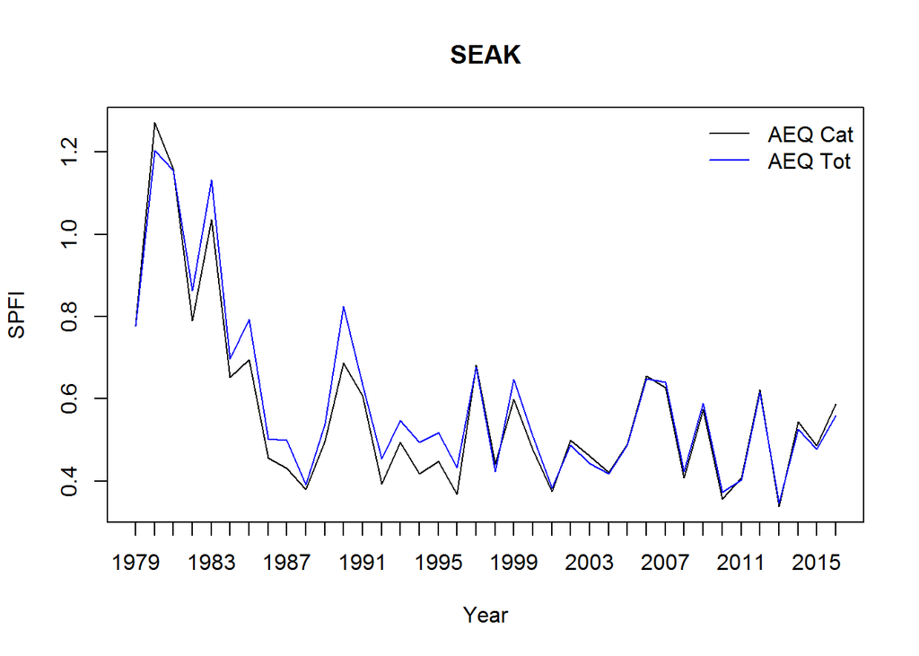

```r
  plot(summary(seak_spfi, unit="aeq cat")$spfi[,1],type="l",xlab="Year",ylab="SPFI",main="SEAK", xaxt="n")
  lines(summary(seak_spfi, unit="aeq tot")$spfi[,1],col="blue")
  legend("topright",c("AEQ Cat", "AEQ Tot"), lty=c(1,1), col=c("black","blue"),bty="n")
  axis(1,at=1:length(1979:2016),labels=1979:2016)
```

# Example 3: 2018ERA NBC AABM Troll for Base Period Calibration

## Create the spfi_input object

```r
#SPFI input data is a list object
 nbc=list()
#Which fisheries?
 nbc$erafisheries = 8
#Combine fisheries?
 nbc$combinefisheries = data.frame(rbind(c(8,1)))
 names(nbc$combinefisheries) = c("ERAFishery","SPFIFishery")
#Stock/age matrix
 nbc$stockage = read.delim("Data/Phase2/nbcTrollbpP2.STF", header=TRUE)
#Catch
 nbc$catch = read.csv("Data/2018ERA_CatchDataforSPFI/nbcTroll7916.CAT",header=FALSE)
 names(nbc$catch) = c("Year","SPFIFishery","SPFIFisheryName","Catch","Addon")
 nbc$catch$SPFIFisheryName = "AllStrata"
 nbc$catch$SPFIFisheryName = as.factor(nbc$catch$SPFIFisheryName)
#Set the object class
 class(nbc) = "spfi_input"
```

Examine the spfi_input object:

```r
 nbc$stockage
```

| StockAcronym | Age2 | Age3 | Age4 | Age5 | Age6 |
| --- | --- | --- | --- | --- | --- |
| RBT | 0 | 1 | 1 | 1 | 0 |
| SRH | 0 | 0 | 1 | 1 | 0 |
| URB | 0 | 0 | 1 | 0 | 0 |
| WSH | 0 | 0 | 1 | 0 | 0 |
| ELK | 0 | 0 | 1 | 0 | 0 |
| QUE | 0 | 0 | 1 | 1 | 0 |
| SHU | 0 | 1 | 1 | 0 | 0 |
| SUM | 0 | 0 | 1 | 1 | 0 |

## Compute SPFI

Note that I have set the hrjtype=“P”.

```r
nbc_spfi <- spfi(spfidat=nbc, hrjdat=z.cy, hrjtype="P")
```

## Summarize the results

### AEQ landed catch

```r
summary(x=nbc_spfi, unit="aeq cat")
```

```
##  Years spfigrand spfibystrata
##   1979      0.87         0.87
##   1980      0.88         0.88
##   1981      1.25         1.25
##   1982      1.00         1.00
##   1983      0.78         0.78
##   1984      0.97         0.97
##   1985      1.15         1.15
##   1986      0.71         0.71
##   1987      0.62         0.62
##   1988      0.45         0.45
##   1989      0.52         0.52
##   1990      0.53         0.53
##   1991      0.66         0.66
##   1992      0.45         0.45
```

[output cut: 24 more lines]

### AEQ total mortality

```r
summary(x=nbc_spfi, unit="aeq tot")
```

```
##  Years spfigrand spfibystrata
##   1979      0.87         0.87
##   1980      0.86         0.86
##   1981      1.27         1.27
##   1982      1.00         1.00
##   1983      0.77         0.77
##   1984      0.94         0.94
##   1985      1.11         1.11
##   1986      0.67         0.67
##   1987      0.64         0.64
##   1988      0.46         0.46
##   1989      0.56         0.56
##   1990      0.57         0.57
##   1991      0.66         0.66
##   1992      0.48         0.48
```

[output cut: 24 more lines]

### Figures

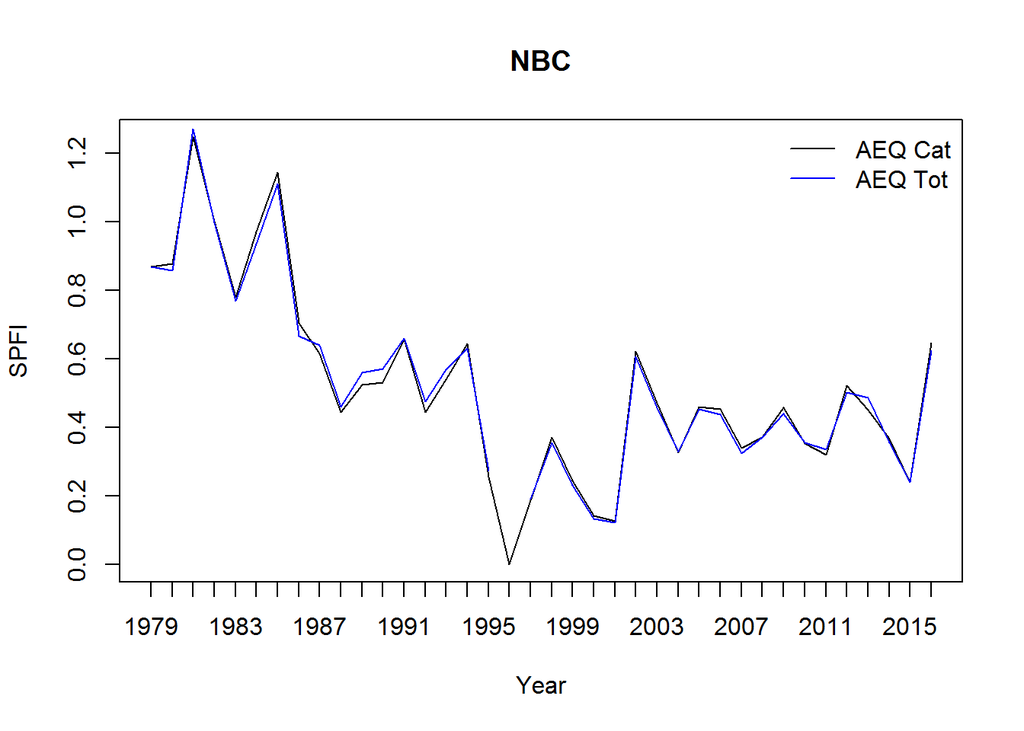

```r
  plot(summary(nbc_spfi, unit="aeq cat")$spfi[,1],type="l",xlab="Year",ylab="SPFI",main="NBC", xaxt="n")
  lines(summary(nbc_spfi, unit="aeq tot")$spfi[,1],col="blue")
  legend("topright",c("AEQ Cat", "AEQ Tot"), lty=c(1,1), col=c("black","blue"),bty="n")
  axis(1,at=1:length(1979:2016),labels=1979:2016)
```

# Example 4: 2018ERA WCVI AABM Troll for Base Period Calibration

## Create the spfi_input object

```r
#SPFI input data is a list object
 wcvi=list()
#Which fisheries?
 wcvi$erafisheries = 10:12
#Combine fisheries?
 wcvi$combinefisheries = data.frame(rbind(c(10,1),c(11,2),c(12,3)))
 names(wcvi$combinefisheries) = c("ERAFishery","SPFIFishery")
#Stock/age matrix
 wcvi$stockage = read.delim("Data/Phase2/wcviTrollbpP2.STF", header=TRUE)
#Catch
 wcvi$catch = read.csv("Data/2018ERA_CatchDataforSPFI/wcviTroll7916.CAT",header=FALSE)
 names(wcvi$catch) = c("Year","SPFIFishery","SPFIFisheryName","Catch","Addon")
#Set the object class
 class(wcvi) = "spfi_input"
```

Examine the spfi_input object:

```r
 wcvi$stockage
```

| StockAcronym | Age2 | Age3 | Age4 | Age5 | Age6 |
| --- | --- | --- | --- | --- | --- |
| GAD | 0 | 1 | 1 | 0 | 0 |
| LRH | 0 | 1 | 1 | 0 | 0 |
| RBT | 0 | 1 | 1 | 0 | 0 |
| SAM | 0 | 1 | 1 | 0 | 0 |
| SPR | 0 | 1 | 1 | 0 | 0 |
| SPS | 0 | 1 | 1 | 0 | 0 |
| SUM | 0 | 0 | 1 | 1 | 0 |
| URB | 0 | 0 | 1 | 0 | 0 |
| WSH | 0 | 0 | 1 | 0 | 0 |
| CHI | 0 | 1 | 1 | 0 | 0 |

[output cut: 4 more lines]

## Compute SPFI

Note that I have set the hrjtype=“P”.

```r
wcvi_spfi <- spfi(spfidat=wcvi, hrjdat=z.cy, hrjtype="P")
```

## Summarize the results

### AEQ landed catch

Without the missing strata adjusment:

```r
summary(x=wcvi_spfi, unit="aeq cat")
```

```
##  Years spfigrand   10   11   12
##   1979      1.09 1.10 1.19 1.02
##   1980      1.17 1.16 1.21 1.15
##   1981      0.84 1.08 0.76 0.83
##   1982      0.89 0.66 0.83 1.00
##   1983      1.00 0.80 0.89 1.19
##   1984      1.41 1.07 0.96 1.74
##   1985      0.00  NaN 0.58 1.55
##   1986      0.80 0.09 0.52 1.37
##   1987      0.00  NaN  NaN 1.40
##   1988      0.00  NaN  NaN 1.64
##   1989      0.00  NaN 0.00 0.92
##   1990      0.00  NaN 0.05 1.81
##   1991      0.00  NaN 0.03 1.26
##   1992      0.00 0.19  NaN 1.77
```

[output cut: 24 more lines]

With the missing strata adjusment:

```r
summary(x=gauntlet(x=wcvi_spfi, method="glm", catchcriteria=4000), unit="aeq cat")
```

```
##  Years spfigrand   10   11   12
##   1979      1.09 1.10 1.19 1.02
##   1980      1.17 1.16 1.21 1.15
##   1981      0.84 1.08 0.76 0.83
##   1982      0.89 0.66 0.83 1.00
##   1983      1.00 0.80 0.89 1.19
##   1984      1.41 1.07 0.96 1.74
##   1985      1.01 0.00 0.58 1.55
##   1986      0.80 0.09 0.52 1.37
##   1987      0.71 0.00 0.00 1.40
##   1988      0.83 0.00 0.00 1.64
##   1989      0.47 0.00 0.01 0.92
##   1990      0.88 0.00 0.05 1.81
##   1991      0.47 0.00 0.03 1.26
##   1992      1.13 0.19 0.04 1.77
```

[output cut: 24 more lines]

### AEQ total mortality

Without the missing strata adjusment:

```r
summary(x=wcvi_spfi, unit="aeq tot")
```

```
##  Years spfigrand   10   11   12
##   1979      1.07 1.07 1.16 1.01
##   1980      1.16 1.15 1.21 1.13
##   1981      0.85 1.08 0.78 0.84
##   1982      0.91 0.69 0.85 1.02
##   1983      0.97 0.77 0.86 1.16
##   1984      1.41 1.07 0.96 1.75
##   1985      0.00  NaN 0.57 1.53
##   1986      0.77 0.08 0.50 1.33
##   1987      0.00  NaN  NaN 1.81
##   1988      0.00  NaN  NaN 1.75
##   1989      0.00  NaN 0.00 1.05
##   1990      0.00  NaN 0.05 1.86
##   1991      0.00  NaN 0.03 1.35
##   1992      0.00 0.21  NaN 1.96
```

[output cut: 24 more lines]

With the missing strata adjusment:

```r
summary(x=gauntlet(x=wcvi_spfi, method="glm", catchcriteria=4000), unit="aeq tot")
```

```
##  Years spfigrand   10   11   12
##   1979      1.07 1.07 1.16 1.01
##   1980      1.16 1.15 1.21 1.13
##   1981      0.85 1.08 0.78 0.84
##   1982      0.91 0.69 0.85 1.02
##   1983      0.97 0.77 0.86 1.16
##   1984      1.41 1.07 0.96 1.75
##   1985      0.99 0.00 0.57 1.53
##   1986      0.77 0.08 0.50 1.33
##   1987      0.92 0.00 0.00 1.81
##   1988      0.89 0.00 0.00 1.75
##   1989      0.53 0.00 0.01 1.05
##   1990      0.91 0.00 0.05 1.86
##   1991      0.50 0.00 0.03 1.35
##   1992      1.25 0.21 0.04 1.96
```

[output cut: 24 more lines]

### Figures

Without the missing strata adjusment:

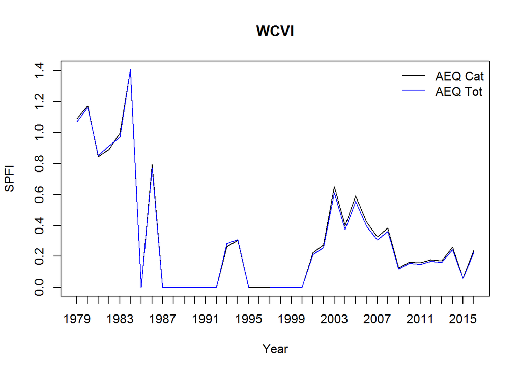

```r
  plot(summary(wcvi_spfi, unit="aeq cat")$spfi[,1],type="l",xlab="Year",ylab="SPFI",main="WCVI", xaxt="n")
  lines(summary(wcvi_spfi, unit="aeq tot")$spfi[,1],col="blue")
  legend("topright",c("AEQ Cat", "AEQ Tot"), lty=c(1,1), col=c("black","blue"),bty="n")
  axis(1,at=1:length(1979:2016),labels=1979:2016)
```

With the missing strata adjusment:

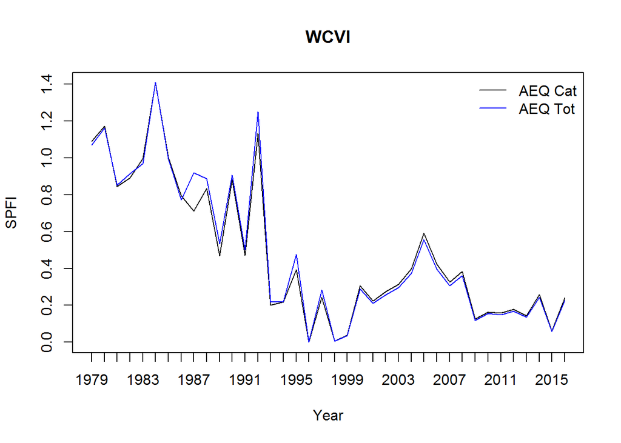

```r
  plot(summary(gauntlet(x=wcvi_spfi, method="glm", catchcriteria=4000), unit="aeq cat")$spfi[,1],type="l",xlab="Year",ylab="SPFI",main="WCVI", xaxt="n")
  lines(summary(gauntlet(x=wcvi_spfi, method="glm", catchcriteria=4000), unit="aeq tot")$spfi[,1],col="blue")
  legend("topright",c("AEQ Cat", "AEQ Tot"), lty=c(1,1), col=c("black","blue"),bty="n")
  axis(1,at=1:length(1979:2016),labels=1979:2016)
```